# Bootstrap and Jackknife

## Q1)

```r
data <- read.csv("UKDriverDeaths.csv")
head(data, 10)
```

```
##     X    x
## 1   1 1687
## 2   2 1508
## 3   3 1507
## 4   4 1385
## 5   5 1632
## 6   6 1511
## 7   7 1559
## 8   8 1630
## 9   9 1579
## 10 10 1653
```

“UKDriverDeaths.csv” gives the monthly totals of car drivers in Great Britain killed or seriously injured 1969 to 1984. (Please note that event of number of killed or injured drivers follow poison distribution with parameter $\lambda$).

Using this dataset;

1. Obtain MLE of $\lambda$ using bootstrap and estimate the bias and standard error of this estimate.

```r
n <- nrow(data)

lambda.hat <- sum(data$x) / n

B <- 1000
lambda.boot <- numeric(B)

for(i in 1:B){
    index <- sample(n, size=n, replace = T)
    lambda.boot[i] <- sum(data$x[index]) / n
}

estimate.lambda <- mean(lambda.boot)
SE <- sd(lambda.boot)

bias <- estimate.lambda - lambda.hat
out <- c(lambda.hat, estimate.lambda, SE, bias)
names(out) <- c("lambda.hat","estimated lambda", "Std.Err", "Bias")
out
```

```
##       lambda.hat estimated lambda          Std.Err             Bias
##       1670.30729       1670.05154         20.35034         -0.25575
```

2. Use the bootstrap to show the distribution of the sample kurtosis. Besides, what is the standard error and bias of the sample kurtosis computed using the bootstrap?

```r
kurtosis_fnc <- function(x,i){
    n <- length(x)
    sample_krts <- mean((x[i] - mean(x[i]))^4) / var(x[i])^2
    return(sample_krts)

}
```

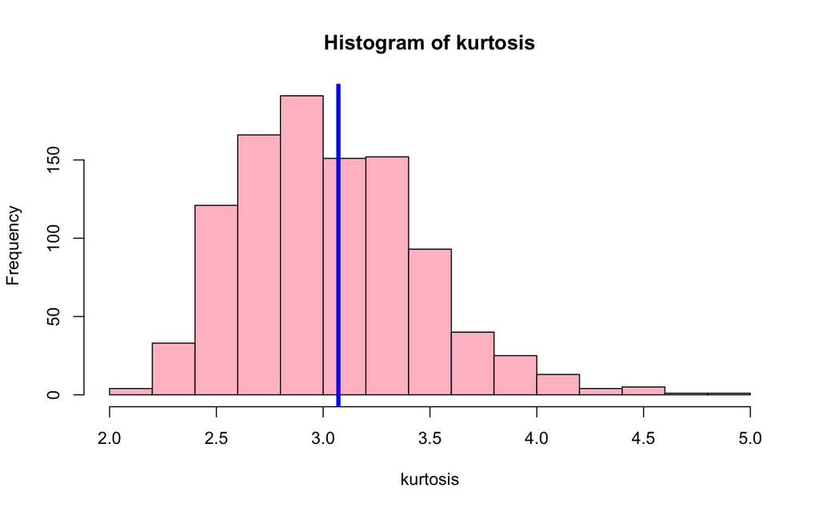

```r
n <- nrow(data)
B <- 1000

kurtosis <- numeric(B)
sample_kurt <- kurtosis_fnc(data$x)

for(i in 1:B){

    index <- sample(n, size=n, replace = T)
    x <- data[index,"x"]
    kurtosis[i] <- kurtosis_fnc(x)
}

est_kurt <- mean(kurtosis)
se_kurt <- sd(kurtosis)
bias_kurt <- (est_kurt - sample_kurt)


hist(kurtosis, col="pink") # the distribution from the bootstrap
abline(v=sample_kurt, col="blue",lwd=4)
```

```r
result <- c(sample_kurt, est_kurt, se_kurt, bias_kurt)
names(result) <- c("sample", "estimated", "std.error","bias")
result
```

```
##      sample   estimated   std.error        bias
##  3.07133848  3.03277946  0.42498278 -0.03855902
```

3. Use the jackknife to show the distribution of the sample skewness. Besides, what is the standard error and bias of the sample skewness computed using the jackknife?

```r
skew <- function(x,i){
    n <- length(x)
    sample_skw <- mean((x[i] - mean(x[i]))^3) / mean((x[i] - mean(x[i]))^2)^(3/2)
    return(sample_skw)

}
```

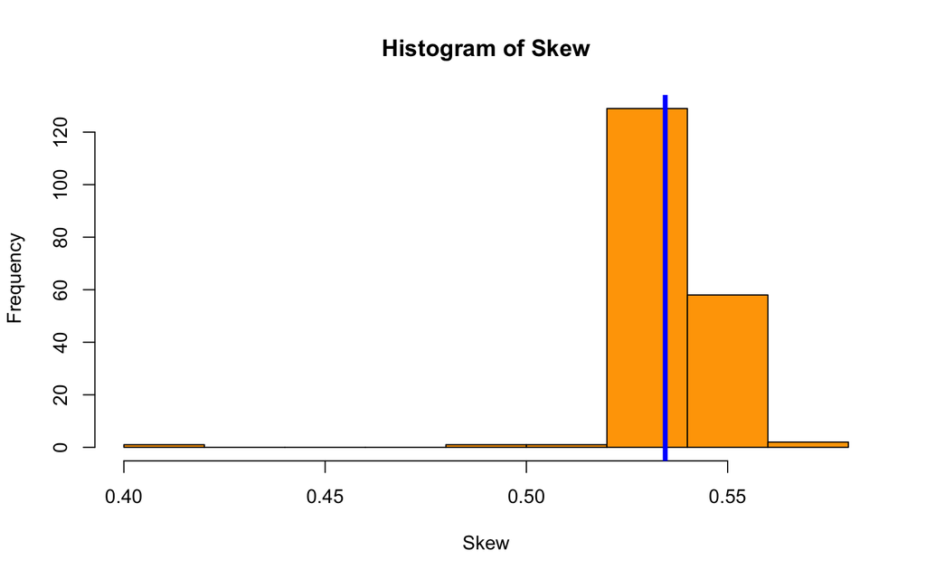

```r
n <- nrow(data)

Skew <-c()
sample_skew <- skew(data$x)

for(i in 1:n){

    Skew[i] <- skew(data$x[-i])
}

est_skew <- mean(Skew)
se_skew <- sqrt((n-1) * mean((sample_skew - mean(Skew))^2))
bias_skew <- (est_skew - sample_skew)*(n-1)


hist(Skew, col="orange") # the distribution from the bootstrap
abline(v=sample_skew, col="blue",lwd=4)
```

```r
result <- c(sample_skew, est_skew, se_skew, bias_skew)
names(result) <- c("sample", "estimated", "std.error","bias")
result
```

```
##     sample  estimated  std.error       bias
##  0.5344923  0.5344336  0.0008118 -0.0112193
```

4. Obtain a 95% bootstrap confidence interval and percentile interval for the variance of killed or injured drivers.

Comment on your results.

```r
alpha <- 0.05
B <- 1000
sample_var <- var(data$x)
n <- nrow(data)

S1 <- S2 <- numeric(B)

for(i in 1:B){
  index1 <- index2 <- sample(1:n, size = n, replace = TRUE)
  S1[i] <- var(data[index1,"x"])
  S2[i] <- var(data[index2,"x"])
}

lower_CI <- (n-1) * mean(S1) / qchisq(1-alpha/2, df=n-1)
upper_CI <- (n-1) * mean(S1) / qchisq(alpha/2, df=n-1)

lower_PI <- quantile(S2, alpha/2)
upper_PI <- quantile(S2, 1-alpha/2)

result <- matrix(c(lower_CI,lower_PI,upper_CI,upper_PI), ncol = 2, dimnames = list(c("Conf.Int","Perc.Int"), c("Lower","Upper")))
result
```

```
##             Lower    Upper
## Conf.Int 69283.68 103582.1
## Perc.Int 68189.19 101708.3
```

OR;

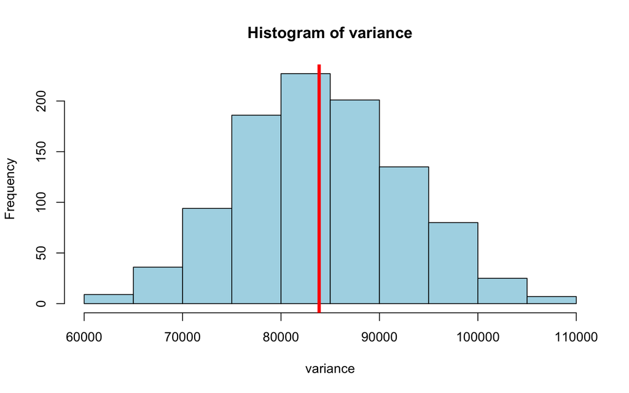

```r
B <- 1000 # bootstrap replicates

variance <- numeric(B)

sample_var <- var(data$x)

for(i in 1:B){
    index <- sample(1:nrow(data), size = nrow(data),replace = TRUE)
    x <- data[index,"x"]
    variance[i] <- var(x)
}

est_var <- mean(variance)
se_var <- sd(variance)
bias_var <- est_var - sample_var


hist(variance, col="lightblue") # the distribution from the bootstrap
abline(v=sample_var, col="red",lwd=4)
```

```r
out <- c(sample_var, est_var, se_var, bias_var)
names(out) <- c("sample variance", "estimated variance", "std.error", "bias")
out
```

```
##    sample variance estimated variance          std.error               bias
##          83874.507          84195.082           8487.937            320.575
```

```r
lower <- est_var - qnorm(1-alpha/2, 0,1) * se_var
upper <- est_var + qnorm(1-alpha/2, 0,1) * se_var

cat("95% confidence interval for eruptions is= (", lower, ",", upper, ")")
```

[output not shown]

```r
lower <- quantile(variance, alpha/2)
upper <- quantile(variance, 1-alpha/2)

cat("95% quatile interval for eruptions is= (", lower, ",", upper, ")")
```

[output not shown]

## Q2)

For this question please use use titanic.csv data data given to you.

Using the ‘titanic’ data;

**a)** Deploy logistic regression model by taking “Survived” as response; “Age”, “Sex” as covariates. Obtain estimates of model coefficients ($\beta_0, \beta_1, \beta_2$) using **JACKKNIFE**. Then, compare the actual model coefficients with jackknife estimates.

**(NOTE: For jackknifing, don’t use built-in function)**

### Logistic Regression without using Jackknife

```r
logit_model <-  glm(Survived ~ Sex + Age, family = binomial,  data = titanic_train2)
summary(logit_model)
```

```
##
## Call:
## glm(formula = Survived ~ Sex + Age, family = binomial, data = titanic_train2)
##
## Deviance Residuals:
##     Min       1Q   Median       3Q      Max
## -1.7405  -0.6885  -0.6558   0.7533   1.8989
##
## Coefficients:
##              Estimate Std. Error z value Pr(>|z|)
## (Intercept)  1.277273   0.230169   5.549 2.87e-08 ***
## Sexmale     -2.465920   0.185384 -13.302  < 2e-16 ***
## Age         -0.005426   0.006310  -0.860     0.39
## ---
## Signif. codes:  0 '***' 0.001 '**' 0.01 '*' 0.05 '.' 0.1 ' ' 1
##
## (Dispersion parameter for binomial family taken to be 1)
##
##     Null deviance: 964.52  on 713  degrees of freedom
## Residual deviance: 749.96  on 711  degrees of freedom
## AIC: 755.96
##
## Number of Fisher Scoring iterations: 4
```

```r
#Construct the Confusion Matrix
prediction <- predict(logit_model, newdata = titanic_train2, type = 'response')
pred <- factor(ifelse(prediction <= 0.5,0,1))
result <- caret::confusionMatrix(pred,factor(titanic_train2$Survived))
result
```

```
## Confusion Matrix and Statistics
##
##           Reference
## Prediction   0   1
##          0 360  93
##          1  64 197
##
##                Accuracy : 0.7801
##                  95% CI : (0.7479, 0.81)
##     No Information Rate : 0.5938
##     P-Value [Acc > NIR] : < 2e-16
##
##                   Kappa : 0.5369
##
##  Mcnemar's Test P-Value : 0.02544
##
##             Sensitivity : 0.8491
##             Specificity : 0.6793
##          Pos Pred Value : 0.7947
##          Neg Pred Value : 0.7548
##              Prevalence : 0.5938
##          Detection Rate : 0.5042
##    Detection Prevalence : 0.6345
##       Balanced Accuracy : 0.7642
##
##        'Positive' Class : 0
##
```

### OR;

```r
library(performance)
performance_accuracy(logit_model)$Accuracy
```

```
## [1] 0.759084
```

### Logistic Regression by using Jackknife

```r
attach(titanic_train2)

coefficients <- matrix(0, nrow = 3, ncol = nrow(titanic_train2)) #create empty matrix
rownames(coefficients) <- c(paste("beta",0:2,sep=""))


for(i in 1:nrow(titanic_train2)){
    for(j in 1:3){

        model <-  glm(Survived ~ Sex + Age, family = binomial,  data = titanic_train2[-i,])
        coefficients[j,i] <- as.matrix(model$coefficients[[j]])
        }
}

detach(titanic_train2)
#coefficients
estimated_coefficients <- apply(coefficients, 1, mean)
estimated_coefficients
```

```
##        beta0        beta1        beta2
##  1.277286468 -2.465941174 -0.005425992
```

**b)** Compare their accuracy measure (like accuracy, sensitivity, specificity) of 4 different models below to estimate ‘Survived’. (i.e. take Survived as your response variable) with jackknife method.

**(NOTE: For jackknifing, don’t use built-in function)**

Comment on your results.

1. $Y_{Survived} = \beta_0 + \beta_1 X_{Age} + \beta_2 X_{Sex} + \epsilon$
2. $Y_{Survived} = \beta_0 + \beta_1 X_{Age} + \beta_2 X_{Sex} + \beta_3 𝑋_{Age}X_{Sex} + \epsilon$
3. $Y_{Survived} = \beta_0 + \beta_1 X_{Age} + \beta_2 X_{Sex} + \beta_3 X_{Age}^2 + \epsilon$
4. $Y_{Survived} = \beta_0 + \beta_1 X_{Age} + \beta_2 X_{Sex} + \beta_3 X_{Age}^2 + \beta_4 X_{Age}^3+ \epsilon$

```r
attach(titanic_train2)

models <- list(as.formula(Survived ~ Sex + Age),
               as.formula(Survived ~ Sex * Age),
               as.formula(Survived ~ Sex + poly(Age,2)),
               as.formula(Survived ~ Sex + poly(Age,3)))

accuracy <- matrix(0, ncol = length(models), nrow = nrow(titanic_train2)) #create empty matrix
colnames(accuracy) <- c(paste("model",1:4,sep=""))

predicted <- matrix(0, ncol = length(models), nrow = nrow(titanic_train2)) #create empty matrix
colnames(predicted) <- c(paste("model",1:4,sep=""))


for(i in 1:nrow(titanic_train2)){
    for(j in 1:4){

        glm <- glm(models[[j]],  family = binomial, data = titanic_train2[-i,])
        accuracy[i,j] <- performance_accuracy(glm)$Accuracy
    }
}


estimated_accuracy <- apply(accuracy,2,mean)
estimated_accuracy
```

```
##    model1    model2    model3    model4
## 0.7665130 0.7870345 0.7634228 0.7860798
```

```r
detach(titanic_train2)
```

## Q3)

For this question please use use “attitude” data in R.

Using the “attitude” data;

**a)** Deploy linear regression model to estimate “rating” using “complaints”, “learning” and “privileges” as covariates. Then, obtain estimates of model coefficients ($\beta_0, \beta_1, \beta_2, \beta_3$) using **BOOT BUILT-IN FUNCTION** in R. Then, compare the actual model coefficients with bootstrap estimates.

```r
attitude <- attitude[c("rating", "complaints", "learning","privileges")]
```

### Linear regression without using BOOT

```r
summary(lm(rating ~ complaints + learning + privileges, data = attitude))
```

```
##
## Call:
## lm(formula = rating ~ complaints + learning + privileges, data = attitude)
##
## Residuals:
##      Min       1Q   Median       3Q      Max
## -11.2012  -5.7478   0.5599   5.8226  11.3241
##
## Coefficients:
##             Estimate Std. Error t value Pr(>|t|)
## (Intercept)  11.2583     7.3183   1.538   0.1360
## complaints    0.6824     0.1288   5.296 1.54e-05 ***
## learning      0.2380     0.1394   1.707   0.0997 .
## privileges   -0.1033     0.1293  -0.799   0.4318
## ---
## Signif. codes:  0 '***' 0.001 '**' 0.01 '*' 0.05 '.' 0.1 ' ' 1
##
## Residual standard error: 6.863 on 26 degrees of freedom
## Multiple R-squared:  0.715,  Adjusted R-squared:  0.6821
## F-statistic: 21.74 on 3 and 26 DF,  p-value: 2.936e-07
```

### Linear regression by using BOOT

```r
library(boot)

reg.coeffs <- function(x, indices) {
  fit.model <- lm(rating ~ complaints + learning + privileges, x[indices,])
  reg.b0 <- fit.model$coefficients[[1]]  # intercept
  reg.b1 <- fit.model$coefficients[[2]]  # regression coefficient
  reg.b2 <- fit.model$coefficients[[3]]  # regression coefficient
  reg.b3 <- fit.model$coefficients[[4]]  # regression coefficient
  return(c(reg.b0, reg.b1, reg.b2, reg.b3))
}
```

```r
reg.boot <- boot(attitude, reg.coeffs, 1000)
summary(reg.boot)
```

```
##           Length Class      Mode
## t0           4   -none-     numeric
## t         4000   -none-     numeric
## R            1   -none-     numeric
## data         4   data.frame list
## seed       626   -none-     numeric
## statistic    1   -none-     function
## sim          1   -none-     character
## call         4   -none-     call
## stype        1   -none-     character
## strata      30   -none-     numeric
## weights     30   -none-     numeric
```

```r
coefs_lm <- as.data.frame(reg.boot$t0)
rownames(coefs_lm) <- c("Beta0", "Beta1", "Beta2","Beta3")
colnames(coefs_lm) <- "Bootstrap Coefficients"

library(dplyr)
library(kableExtra)

kbl(coefs_lm) %>%
  kable_classic("striped", full_width = T) %>%
  column_spec(1, bold = T, background = "lavender")%>%
  row_spec(0, background = "mediumslateblue",bold = T)
```

[output not shown]

**b)** After deploying model with bootstrap, obtain sampling distributions of $\beta_0, \beta_1, \beta_2, \beta_3$ coefficients. (Make a histogram of their distributions.)

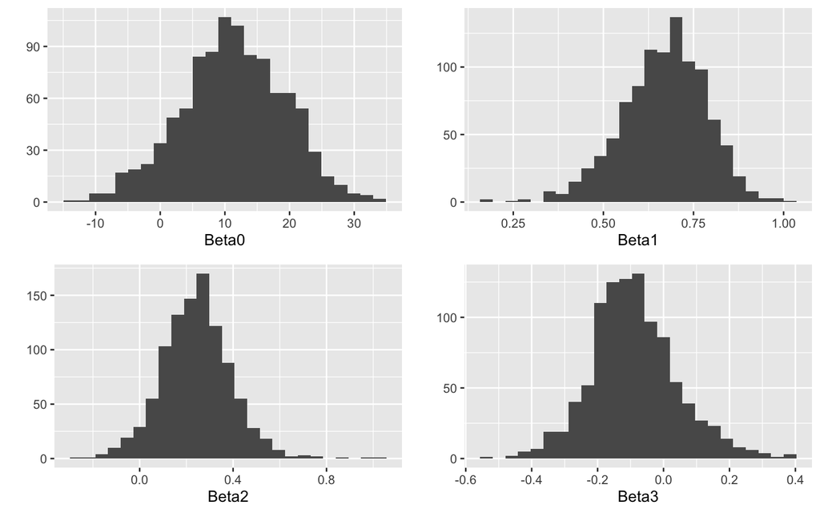

```r
library(ggplot2)
library(ggpubr)

a <- quickplot(reg.boot$t[,1], bins = 25, xlab="Beta0")
b <- quickplot(reg.boot$t[,2], bins = 25, xlab="Beta1")
c <- quickplot(reg.boot$t[,3], bins = 25, xlab="Beta2")
d <- quickplot(reg.boot$t[,4], bins = 25, xlab="Beta3")

ggarrange(a,b,c,d, ncol = 2, nrow = 2, legend = F, common.legend = F)
```

**c)** Suggest 3 different model to estimate “rating” using “complaints”, “learning” and “privileges” as covariates. Compare AIC and Adjusted R-squared values of these 3 models using bootstrap method. **(NOTE: For part c, don’t use built-in function for bootstrap)**

Comment on your results.

```r
library(stats)

attach(attitude)

models <- list(as.formula(rating ~ complaints + learning + privileges),
               as.formula(rating ~  complaints*learning*privileges),
               as.formula(rating ~ complaints + learning + privileges + learning*privileges),
               as.formula(rating ~ complaints))


AIC <- matrix(0, ncol = length(models), nrow = nrow(attitude))
colnames (AIC) <- c(paste("model",1:4,sep=""))

Adj_Rsquared <- matrix(0, ncol = length(models), nrow = nrow(attitude))
colnames (Adj_Rsquared) <- c(paste("model",1:4,sep=""))

n <- nrow(attitude)

for(i in 1:n){
    for(j in 1:length(models)){
        i <- sample(n,n, replace = T)
        model <- lm(models[[j]], data = attitude[i,])
        AIC[i,j] <- AIC(model, k=2)
        Adj_Rsquared[i,j] <- summary(model)$adj.r.squared
    }

}
detach(attitude)

comp_AIC <- as.data.frame(apply(AIC,2,mean))
colnames(comp_AIC) <- c("AIC")


comp_R <- as.data.frame(apply(Adj_Rsquared,2,mean))
colnames(comp_R) <- c("Adjusted R-squared")

result <- cbind(comp_AIC, comp_R)



library(dplyr)
library(kableExtra)

kbl(result) %>%
  kable_classic("striped", full_width = T) %>%
  column_spec(1, bold = T, background = "lavender")%>%
  row_spec(0, background = "mediumslateblue",bold = T)
```

|  | AIC | Adjusted R-squared |
| --- | --- | --- |
| model1 | 207.0690 | 0.6658971 |
| model2 | 205.5624 | 0.6942879 |
| model3 | 204.8609 | 0.6857200 |
| model4 | 205.5813 | 0.6659732 |